# ECS 132 - Homework 2

Sam Tsoi, sgtsoi@ucdavis.edu, 913032178

10/8/2018

# Problem 1 / Independence of Events

For the following events A and B, as defined as A: The first card is a Red Card (Hearts or Diamonds). B: the second card is a Number Card (cards 2 through 10 of any suit). $P(A) = 1/2$ $P(B) = 9*4/52 = 36/52 = 9/13$  
$P (A \cap B) = 0$ because the deck is shuffled each draw and it is replaced. Whether the second first card is drawn to be red does not affect  
whether the second card is a number card, and vice versa. So $P (A \cup B) = P(A) + P(B) - P(A \cap B) = 1.1923$ Therefore, events A and B are independent.

by adding 4 Kings of Hearts, $P(A) = (30/56)$ and $P(B) = 36/56$ $P (A \cap B) = 0$ for the same reason above. The drawing of the first card is replaced and shuffled and would not change the probability  
that the next card drawn. $P (A \cup B) = P(A) + P(B) - P(A \cap B) = 30/56 + 36/56 - 0 = 1.1786$

# Problem 2 / Conditional Probability

Given at least one of two is heads. Therefore, suppose S is the set of all the possible outcomes by that friend, S = {HT, TH, HH}. Given S, suppose T is the probability that the first coin is head, T = {HT, HH}

Therefore, P(T|S) = 2/3  
(this is derived from T/S, which is {HT, HH} / {HT, TH, HH}). The probability that the first coin is heads given the information is 2/3.

# Problem 3 / Bayes’ Rule

$P(A) = .15

P(Defective|A) = .04

P(B) = .35

P(Defective|B) = .03

P(C) = .50

P(Defective|C) = .02

To find $P(A|Defective)$, We need to use Bayes’ Rule, hence $P(A|Defective) = \frac{P(A) *P(Defective|A)}{P(Defective)}$.

Given the law of total probability, $P(Defective) = (.5)(.02)+(.35)(.03)+(.15)(.04)$ =

```
## [1] 0.0265
```

So, $P(A|Defective) = \frac{.15*.04}{P(Defective)} = \frac{.15*.04}{0.0265}$ =

```
## [1] 0.2264151
```

Therefore, the probability that the defective chip came from supplier A is 0.2264151.

# Problem 4 / Random Variables

## 4.1

Let X be a random variable that denotes the sum of the values on a roll of 2 dice. X = {2,3,4,5,6,7,8,9,10,11,12}  
2,3,4,5,6,7,8,9,10,11,12 are all the possible values X can take.

## 4.2

Given $p_j= P(X = a_j)$ for all j where $p_j ≥ 0 and ∑j pj= 1$, $x_i$ = {2,3,4,5,6,7,8,9,10,11,12}  
$P(x_i)$ = {1/36, 2/36, 3/36, 4/36, 5/36, 6/36, 5/36, 4/36, 3/36, 2/36, 1/36}

Note that the sum of $P(x_i)$ = 1.

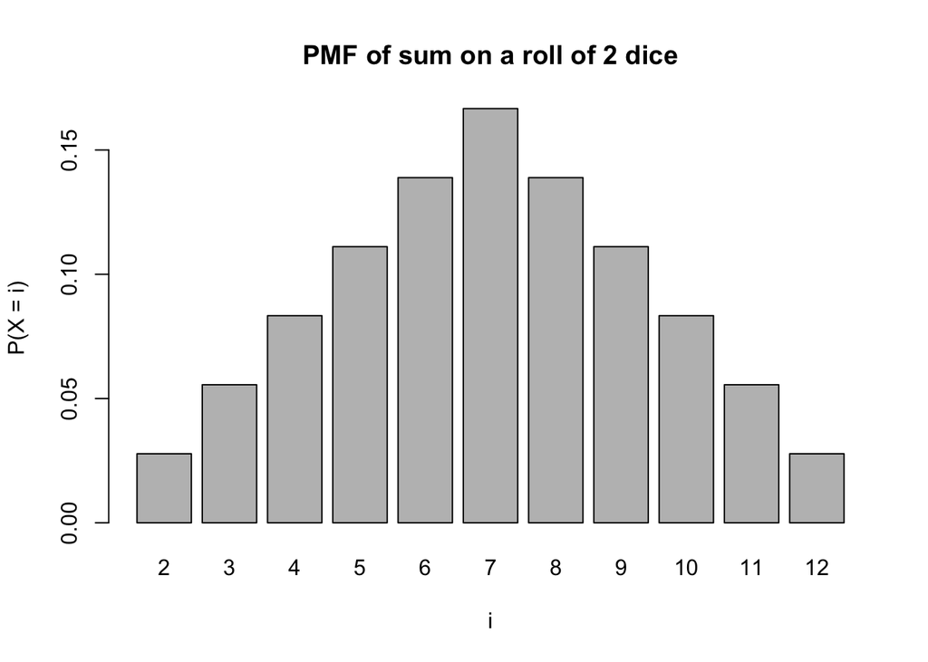

## 4.3

Given the barplot above, E(X) = 7 and P(X = 7) = .166667

The expected value of X is 7.

# Problem 5 / The Binomial Distribution

Suppose that the microchip a company produces passes inspection at a 95% rate. If the company sends 10 chips out for inspection.

## 5.1

Let X be a random variable that how many companies pass inspection for their microchip $x_i$ = {0,1,2,3,4,5,6,7,8,9,10}

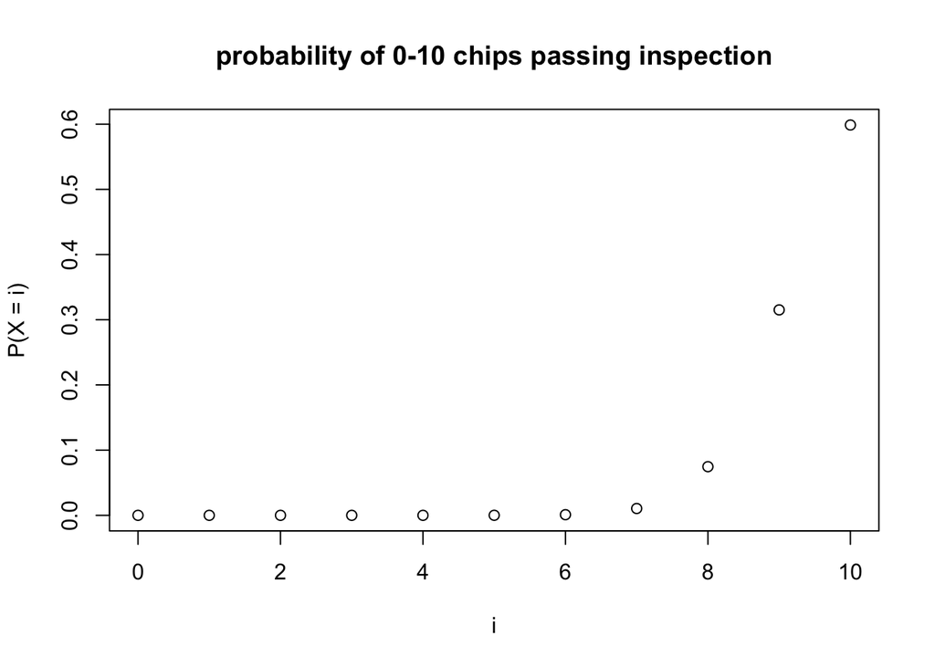

```r
px0 = choose(10, 0)*((.95)^0)*((1-.95)^10)
px1 = choose(10, 1)*((.95)^1)*((1-.95)^9)
px2 = choose(10, 2)*((.95)^2)*((1-.95)^8)
px3 = choose(10, 3)*((.95)^3)*((1-.95)^7)
px4 = choose(10, 4)*((.95)^4)*((1-.95)^6)
px5 = choose(10, 5)*((.95)^5)*((1-.95)^5)
px6 = choose(10, 6)*((.95)^6)*((1-.95)^4)
px7 = choose(10, 7)*((.95)^7)*((1-.95)^3)
px8 = choose(10, 8)*((.95)^8)*((1-.95)^2)
px9 = choose(10, 9)*((.95)^9)*((1-.95)^1)
px10 = choose(10, 10)*((.95)^10)*((1-.95)^0)

x = c(0,1,2,3,4,5,6,7,8,9,10)
y = c(px0,px1,px2,px3,px4,px5,px6,px7,px8,px9,px10)
plot(x,y,xlab ="i",ylab="P(X = i)", main = "probability of 0-10 chips passing inspection")
```

## 5.2

P(at least 2 of the chips fails inspection) = P(at most 8 of the chips pass inspection) = P(X <= 8) = 1 - P(X=10) - P(X=9) =

```r
1-px10-px9
```

```
## [1] 0.08613836
```

# Problem 6 / The Monty Hall Problem

## 6.1

The contestant should switch curtains, because initially, when the contestant chooses a curtain, there is a 1/3 chance that it is a car and 2/3 that it is a goat. A curtain that he or she has not chosen that is revealed a goat which leaves the other curtain that is not chosen 2/3 and the current curtain 1/3. if you don’t switch, the probability of getting the car is 1/3, thus the probability of getting the goat is 2/3. if you do switch, there is 2/3 chance that you initially picked the goat, and when the goat is revealed, you will pick the car. so there is 2/3 chance of picking the car when you do switch. in order to get the goat, you would have to pick the car before switching. this probability is 1/3. so the probability of getting the car when you switch is 2/3 and the probability of getting the car if you do not switch is 1/3. So you should switch!

## 6.2

```r
m = 1000 # number of samples to simulate
curtains = c(0,0,1) #1 if curtain has car, 0 if goat
prob = numeric(m)
i = 2
for (i in 1:m)
{

  pick = sample(1:3, 1) #1,2, or 3
  if(curtains[pick] == 1) #if contestant picked curtain with car at first
  {
    #doesn't matter which other curtain he chooses, both of them will be goat
    switch = sample(1:2,1)
  }
  else #if contestant picked curtain with goat, then the one revealed is known (the other one with goat)
  {
    #if picked 1, reveal must be 2, so switch must be to 3
    if(pick == 1)
    {
      switch = 3
    }
    #if picked 2, reveal must be 1, so switch must be to 3
    if(pick == 2)
    {
      switch = 3
    }
  }


  if(curtains[switch] == 1)
  {
    prob[i] = 1
  }
  else
  {
    prob[i] = 0
  }

}
#probability of winning the car =  # of 1s in prob/total number of trials
disp = as.data.frame(table(prob))
disp$probability = disp$Freq/m
disp
```

```
##   prob Freq probability
## 1    0  339       0.339
## 2    1  661       0.661
```

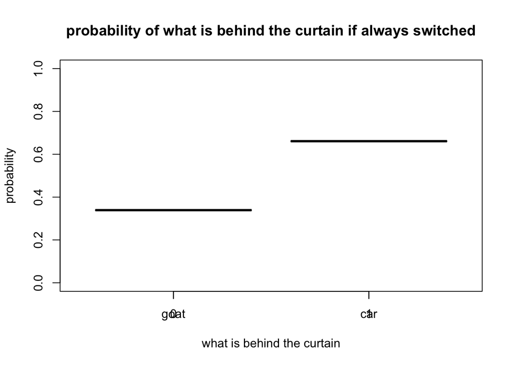

```r
plot(disp$prob, disp$probability, xlab = "what is behind the curtain", ylab = "probability", ylim = c(0,1), main = "probability of what is behind the curtain if always switched")
axis(1, at=1:2, labels=c('goat','car'))
```

# Classmate Collaborators

Include the names and email IDs of everyone you collaborated with.

1. Kayla Peters, {kaypeters} [at] ucdavis [dot] edu, 913627392